# Apache Parquet による前処理の高速化

Osamu Morimoto

2024-06-02

## Apache Parquet とは

Apache Parquet はオープンソースの列指向データファイルフォーマットで、効率的なデータの保存と検索のために設計されています。

複雑なデータを一括処理するための高性能な圧縮とエンコード方式を提供し、多くのプログラミング言語と分析ツールでサポートされています。

Rの場合、arrowパッケージを使うことで Apache Parquet を扱うことができます。

まず必要なパッケージを読み込みます。

```r
library(conflicted)
library(tidyverse)
library(arrow)
library(microbenchmark) #処理速度測定のため
```

サンプルデータを`read_parquet()`関数で読み込みます。

この時、デフォルトではデータフレームとして、引数`as_data_frame = FALSE`を付けると Arrow Table として読み込まれます。

```r
# データフレームとして
reservation_df <- read_parquet(
  "https://github.com/ghmagazine/awesomebook_v2/raw/main/data/reservation.parquet"
  )

#Arrow Table として
reservation_at <- read_parquet(
  "https://github.com/ghmagazine/awesomebook_v2/raw/main/data/reservation.parquet",
  as_data_frame = FALSE
  )
```

Arrow Table も通常のデータフレーム同様tidyverseで扱えますが、処理の最後に`collect()`関数を実行しないと結果が得られません。

データフレームによる以下の処理を考えます。

```r
reservation_df |>
  dplyr::filter(status != "canceled") |>
  summarise(
    reservation_cnt = n(),
    .by = c(hotel_id, customer_id)
    )
```

同じ処理を Arrow Table で行うにはこうします。 最後に`collect()`が加わっただけです。

```r
reservation_at |>
  dplyr::filter(status != "canceled") |>
  summarise(
    reservation_cnt = n(),
    .by = c(hotel_id, customer_id)
    ) |>
  collect() #この処理が加わっただけ
```

処理の速さを比べてみましょう。

```r
df <- function() {
  reservation_df |>
    dplyr::filter(status != "canceled") |>
    summarise(
      reservation_cnt = n(),
      .by = c(hotel_id, customer_id)
    )
}

at <- function() {
  reservation_at |>
    dplyr::filter(status != "canceled") |>
    summarise(
      reservation_cnt = n(),
      .by = c(hotel_id, customer_id)
    ) |>
    collect() #この処理が加わっただけ
}

set.seed(1234)
res <- microbenchmark(
  data_frame = df(),
  arrow_table = at(),
  times = 100
  )
```

```r
summary(res)
```

```
##          expr        min         lq      mean     median         uq        max
## 1  data_frame 15111.2864 15973.1028 16948.943 16409.7643 17651.8857 23159.4643
## 2 arrow_table   433.8274   458.3987   489.048   473.6471   492.2276   830.4927
##   neval
## 1   100
## 2   100
```

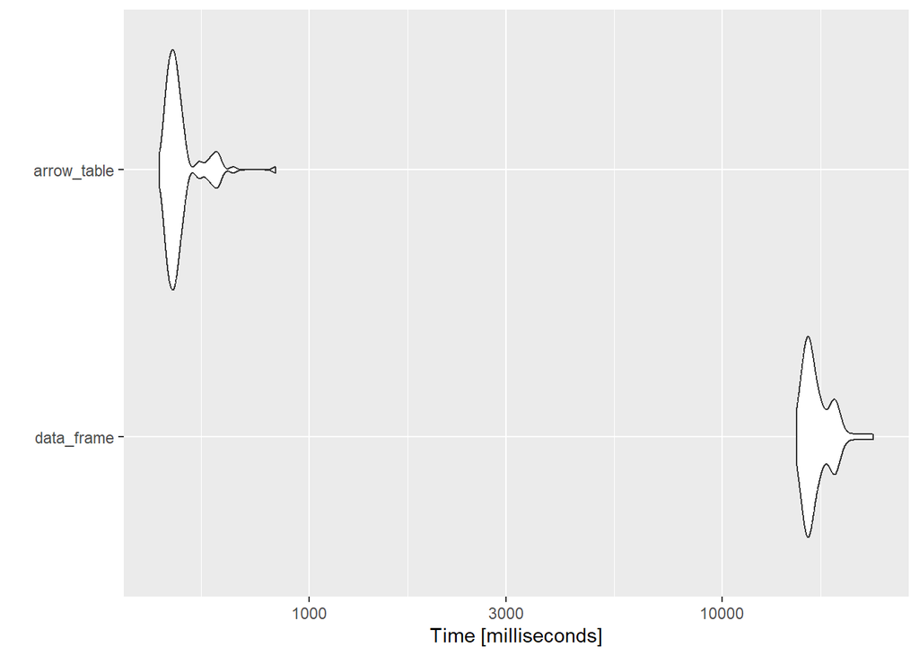

```r
autoplot(res)
```

環境によって変わりますが、私の貧弱なノートPCでざっと35倍の速さです！

Tidyverseのすべての処理にApache Parquetが対応しているわけでないのですが、前処理がかなり快適になるので積極的に Apache Parquet を使っていきましょう！

以下の資料も参考になります。

[Apache Arrow 鬼はええ！このままCSV全部Parquetに変換していこうぜ！](https://eitsupi.github.io/tokyorslide/tokyor_97)

[arrowパッケージの基礎](https://uribo.quarto.pub/hello-r-arrow/)

以上です。

Topへ